# Using scvelo to recover and analyze RNA velocity

More info on the official [scvelo documentation](https://scvelo.readthedocs.io/about.html).

### Installation

To install conda, please follow this [link](https://conda.io/projects/conda/en/latest/user-guide/install/index.html)

After installing conda, you will need to create a new conda environment, and install scvelo in this environment (all the following lines must be executed in the terminal).

```python
! conda create --name scvelo_env python=3.9 anaconda
! conda activate scvelo_env
! pip install -U scvelo
```

You've now installed conda and scvelo. Next time, before lauching a new notebook, you will need to activvate the environment you created.

```python
! conda activate scvelo_env
! jupyter notebook
```

And then you can open the notebook in the environment where scvelo is installed.

### Packages

First step is to import all the needed packages. `copy` is not mandatory, and may in fact never be used, but can be useful if you don't want to modify the base data when creating a new object from an existing one. All these packages are already base python packages, or come with scvelo and are installed at the same time.

```python
import scvelo as scv
import pandas as pd
import copy
import pickle
import os
import csv
import anndata
```

After importing scvelo, you can verify the version.

```python
scv.logging.print_version()
```

```
Running scvelo 0.2.4 (python 3.9.4) on 2021-09-08 14:50.
```

## Load the Data

There are several ways to load the data. Using a `.loom` file from velocyto and the metadata from Seurat in `.csv`, Using the **spliced** and **unspliced** assays from a Seurat object in csv or loading an exemple dataset from the scvelo datasets.

In this tutorial we will just load an exemple dataset from scvelo.

```python
adata = scv.datasets.dentategyrus()
```

You can visualize the spliced/unspliced proportions, to verify that both are well loaded, and the quality of the dataset.

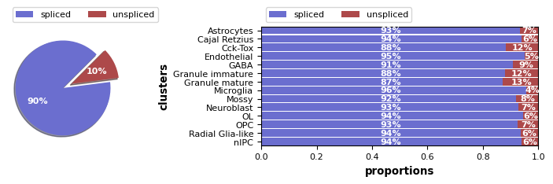

```python
scv.pl.proportions(adata)
```

## Preprocessing the Data

Preprocessing consist of gene selection by minimum counts, normalizing every cell by its total size, gene selection by dispersion and logarithmizing X (assay RNA in Seurat). All these steps are ran when running `scv.pp.filter_and_normalize`. Analysis further require first and second order moments (means and uncenterd variance) among nearest neighbors in PCA space. You can change the parameters as you want, here are the default values. Note that the more cells you have, the more you can increase `n_neighbors`. If you only have very few cells, you might want to reduce this parameter. You can also change the number of top genes to keep, but the more genes, the longer the velocity recovery will take.

```python
scv.pp.filter_and_normalize(adata, min_shared_counts=20, n_top_genes=2000)
scv.pp.moments(adata, n_pcs=30, n_neighbors=30)
```

```
Filtered out 10340 genes that are detected 20 counts (shared).
Normalized count data: X, spliced, unspliced.
Extracted 2000 highly variable genes.
Logarithmized X.
computing neighbors
    finished (0:00:03) --> added
    'distances' and 'connectivities', weighted adjacency matrices (adata.obsp)
computing moments based on connectivities
    finished (0:00:00) --> added
    'Ms' and 'Mu', moments of un/spliced abundances (adata.layers)
```

## Estimate RNA velocity

### Dynamical method

The dynamical method requires another step, which learn the full transcriptional dynamics of splicing kinetics. It takes much longer than the stochastic or deterministic methods, but is the most precise of all. On 2 930 cells and 2 000 genes it takes 5 minutes to retrieve the full splicing kinetics, without parallelization.

```python
scv.tl.recover_dynamics(adata) # the most time consuming step

scv.tl.velocity(adata, mode='dynamical')
scv.tl.velocity_graph(adata)
```

```
recovering dynamics (using 1/40 cores)
```

```
    finished (0:05:18) --> added
    'fit_pars', fitted parameters for splicing dynamics (adata.var)
computing velocities
    finished (0:00:02) --> added
    'velocity', velocity vectors for each individual cell (adata.layers)
computing velocity graph (using 1/40 cores)
```

```
    finished (0:00:06) --> added
    'velocity_graph', sparse matrix with cosine correlations (adata.uns)
```

### Visualize the velocity

There are 3 plotting methods to visualize the velocity on a UMAP. The grid, the stream and the base (my personnal favorite is the stream, but the base one might be better for a small number of cells). There are many grahical parameters that can be changed, see the [documentation](https://scvelo.readthedocs.io/api.html) for more info.

```
computing velocity embedding
    finished (0:00:00) --> added
    'velocity_umap', embedded velocity vectors (adata.obsm)
```

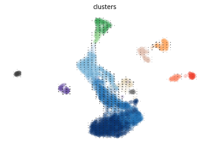

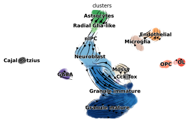

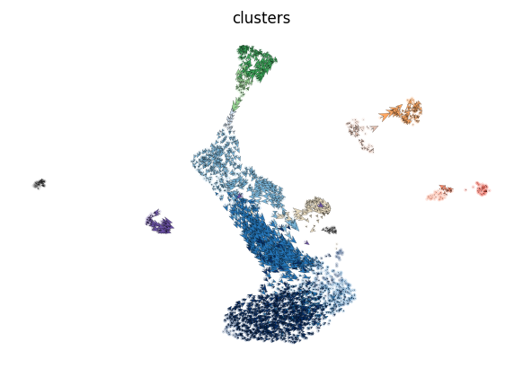

```python
scv.pl.velocity_embedding_grid(adata, basis='umap', color='clusters')
scv.pl.velocity_embedding_stream(adata, basis='umap', color='clusters')
scv.pl.velocity_embedding(adata, arrow_length=4, arrow_size=4, dpi=120, color='clusters')
```

The object containing all the data from scvelo can be saved and read later in python.

```python
pickle.dump(adata, open('/mnt/Data1/public_vignettes/scvelo_data/dentate_gyrus.dp', 'wb'))
```

## Identify important genes

To identify the genes responsible of the highest velocity in each of the clusters, you can use the following command. You can group the genes by whatever column you want, as long as can have categories.

```python
scv.tl.rank_velocity_genes(adata, groupby='clusters', min_corr=.3)


df = scv.DataFrame(adata.uns['rank_velocity_genes']['names'])
df.head(10)
```

```
ranking velocity genes
    finished (0:00:01) --> added
    'rank_velocity_genes', sorted scores by group ids (adata.uns)
    'spearmans_score', spearmans correlation scores (adata.var)
```

|  | Astrocytes | Cajal Retzius | Cck-Tox | Endothelial | GABA | Granule immature | Granule mature | Microglia | Mossy | Neuroblast | OL | OPC | Radial Glia-like | nIPC |
| --- | --- | --- | --- | --- | --- | --- | --- | --- | --- | --- | --- | --- | --- | --- |
| 0 | Bcl2 | Nfix | Nrxn3 | Prex2 | 4933404O12Rik | Schip1 | Slit1 | Hn1 | Nrxn3 | Trim2 | Hepacam | Mrps5 | Hepacam | Atp1a2 |
| 1 | Serpine2 | Nfib | Rnf138 | Serpine2 | Ccdc85a | Rtn4rl1 | Nrgn | Rps27l | Fxyd1 | Mycbp2 | Hmgcs1 | Hmgcs1 | Cspg5 | Pgp |
| 2 | Nfib | Rnf138 | Pgbd5 | Clic4 | Calb1 | Kcnc4 | Fsd1 | Irf9 | Rnf138 | Epha4 | Arrdc2 | Sash1 | Mt1 | Gm17750 |
| 3 | Rnf138 | Pgp | Smarcc1 | Irf9 | 2310009B15Rik | Ptchd4 | Slc17a7 | Qk | Tubgcp2 | Gria2 | Daam2 | Slc1a3 | Sash1 | Gcc2 |
| 4 | Cuta | Nsg2 | 2700062C07Rik | Reep5 | Nfx1 | Slc17a7 | Syt1 | Reep5 | Uchl3 | Cplx2 | Ptn | Gm17750 | Gpc5 | Tmsb10 |
| 5 | Gpc5 | Mt2 | 2310009B15Rik | 2700062C07Rik | Plekha2 | Brinp1 | 2010300C02Rik | Clic4 | Itgb1bp1 | Ppp3ca | Mt1 | Nfib | Irf9 | Tspan7 |
| 6 | Rp9 | Pnp | Stmn2 | Arrdc2 | Pcdh17 | Sntb2 | Grasp | Gcc2 | Mycbp2 | Igf2bp3 | Smarcc1 | 2810459M11Rik | Prex2 | Ptn |
| 7 | Qk | Smarcc1 | Nfx1 | Mtss1 | Hn1 | Syt1 | Camk2a | Lix1 | Gdpd1 | Ahi1 | Chgb | Gcc2 | Gcc2 | Pkia |
| 8 | Ptn | Atp2b1 | Stxbp6 | 2310009B15Rik | Syndig1 | Rapgef4 | Stmn4 | Uchl3 | 2310009B15Rik | Syndig1 | Cuta | Nrxn3 | Fxyd1 | Itgb1bp1 |
| 9 | Cspg5 | 4933404O12Rik | Hmgcs1 | Bcl2 | Gria2 | Vsnl1 | Mtus2 | Serpine2 | Ahi1 | Ctnnd2 | Atp2b1 | Pkia | Qk | Hmgcs1 |

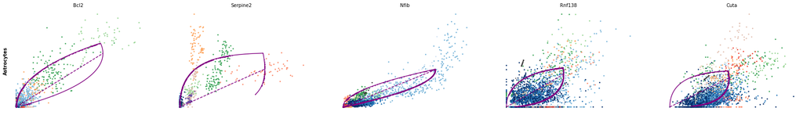

```python
scv.pl.scatter(adata, df['Astrocytes'][:5], ylabel='Astrocytes', frameon=False, size=30, linewidth=1.5, color='clusters')
```

## Pseudotime

Scvelo can compute its own pseudotime, based on a random-walk distance measures on the velocity graph. It measures the average number of steps it takes to reach a cell after start walking from one of the root cells. Scvelo infers the root cell implicitly from the velocity grpah.

```
computing terminal states
WARNING: Uncertain or fuzzy root cell identification. Please verify.
    identified 5 regions of root cells and 4 regions of end points .
    finished (0:00:00) --> added
    'root_cells', root cells of Markov diffusion process (adata.obs)
    'end_points', end points of Markov diffusion process (adata.obs)
```

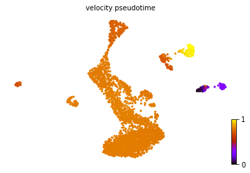

```python
scv.tl.velocity_pseudotime(adata)
scv.pl.scatter(adata, color='velocity_pseudotime', cmap='gnuplot')
```

## Latent time

Latent time works only with the dynamical model, and it show the latent time of the underlying process. The latent time represents the cell's internal clock and approximates the real time experienced by cells as they differentiate, based only on its transcriptional dynamics. It is often very close to the pseudotime.

```
computing latent time using root_cells as prior
    finished (0:00:00) --> added
    'latent_time', shared time (adata.obs)
```

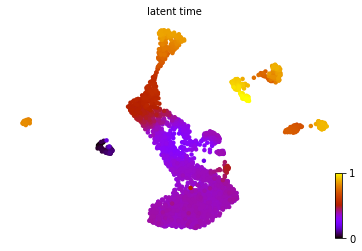

```python
scv.tl.latent_time(adata)
scv.pl.scatter(adata, color='latent_time', color_map='gnuplot', size=80)
```

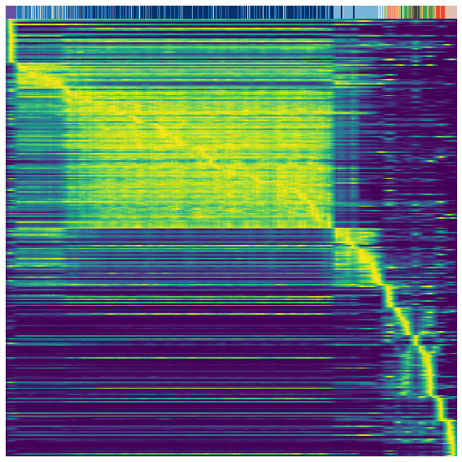

```python
top_genes = adata.var['fit_likelihood'].sort_values(ascending=False).index[:300]
scv.pl.heatmap(adata, var_names=top_genes, sortby='latent_time', col_color='clusters',
               n_convolve=50, yticklabels=False, figsize=(8, 8))
```

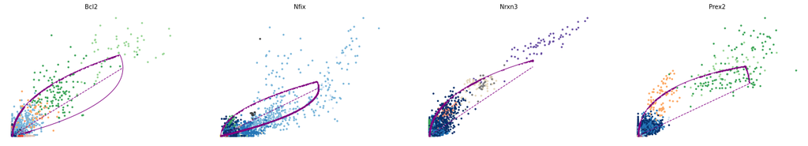

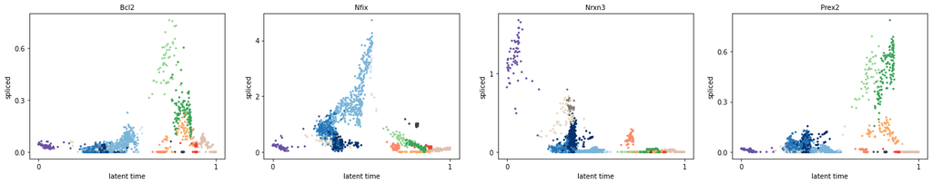

```python
var_names = ['Bcl2', 'Nfix',  'Nrxn3', 'Prex2']
scv.pl.scatter(adata, var_names, frameon=False)
scv.pl.scatter(adata, x='latent_time', y=var_names, frameon=True)
```

The clusters outside of the main supercluster are inducing errors in the latent time and pseudotime calculus, as they also are part of a developpemental process, but not related to the one in the supercluster. To address this issue, we have to remove these unwanted clusters and keep only the clusters of interest.

## Subset the anndata object

You can subset the object using cluster identity, keeping only clusters of interest. The goal here is to have a better and more precise velocity on the clusters of interest.

```python
adata = scv.datasets.dentategyrus()
adata = adata[adata.obs['clusters'].isin(['Astrocytes','Radial Glia-like', 'nIPC', 'Neuroblast', 'Mossy', 'Cck-Tox', 'Granule immature', 'Granule mature'])]
```

Now we can rerun the analysis with onlythe clusters of interest.

```python
scv.pp.filter_and_normalize(adata, min_shared_counts=20, n_top_genes=2000)
scv.pp.moments(adata, n_pcs=30, n_neighbors=30)

scv.tl.recover_dynamics(adata, n_jobs = 32) # the most time consuming step

scv.tl.velocity(adata, mode='dynamical')
scv.tl.velocity_graph(adata)
```

```
Filtered out 170 genes that are detected 20 counts (shared).
WARNING: Did not normalize X as it looks processed already. To enforce normalization, set `enforce=True`.
WARNING: Did not normalize spliced as it looks processed already. To enforce normalization, set `enforce=True`.
WARNING: Did not normalize unspliced as it looks processed already. To enforce normalization, set `enforce=True`.
Skip filtering by dispersion since number of variables are less than `n_top_genes`.
WARNING: Did not modify X as it looks preprocessed already.
computing moments based on connectivities
    finished (0:00:00) --> added
    'Ms' and 'Mu', moments of un/spliced abundances (adata.layers)
recovering dynamics (using 32/40 cores)
```

```
    finished (0:00:23) --> added
    'fit_pars', fitted parameters for splicing dynamics (adata.var)
computing velocities
    finished (0:00:01) --> added
    'velocity', velocity vectors for each individual cell (adata.layers)
computing velocity graph (using 1/40 cores)
```

```
    finished (0:00:05) --> added
    'velocity_graph', sparse matrix with cosine correlations (adata.uns)
```

```
computing velocity embedding
    finished (0:00:00) --> added
    'velocity_umap', embedded velocity vectors (adata.obsm)
```

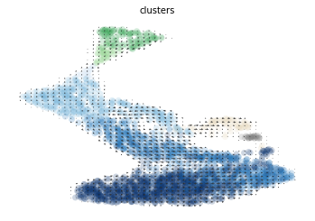

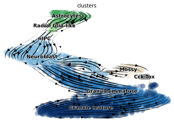

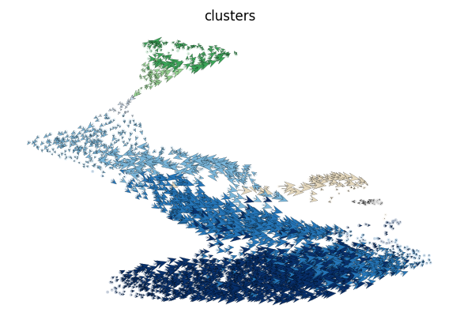

```python
scv.pl.velocity_embedding_grid(adata, basis='umap', color='clusters')
scv.pl.velocity_embedding_stream(adata, basis='umap', color='clusters')
scv.pl.velocity_embedding(adata, arrow_length=4, arrow_size=4, dpi=120, color='clusters')
```

## Identify important genes

To identify the genes responsible of the highest velocity in each of the clusters, you can use the following command. You can group the genes by whatever column you want, as long as it can have categories.

```python
scv.tl.rank_velocity_genes(adata, groupby='clusters', min_corr=.3)


df = scv.DataFrame(adata.uns['rank_velocity_genes']['names'])
df.head(10)
```

```
ranking velocity genes
    finished (0:00:01) --> added
    'rank_velocity_genes', sorted scores by group ids (adata.uns)
    'spearmans_score', spearmans correlation scores (adata.var)
```

|  | Astrocytes | Cck-Tox | Granule immature | Granule mature | Mossy | Neuroblast | Radial Glia-like | nIPC |
| --- | --- | --- | --- | --- | --- | --- | --- | --- |
| 0 | Nfib | 2700062C07Rik | Tmeff2 | Slc39a6 | Otub2 | Nap1l1 | Id2 | Tmsb10 |
| 1 | Cuta | Rorb | Schip1 | Slit1 | Fxyd1 | Syndig1 | Ptn | Gm17750 |
| 2 | Rps24 | Rps24 | Cdh9 | Csgalnact1 | Nol11 | Cplx2 | Mt1 | Gcc2 |
| 3 | Bcl2 | Plekha2 | Cspg5 | Grasp | Gdpd1 | Igf2bp3 | Hepacam | 2700062C07Rik |
| 4 | Zbtb20 | Dtna | Col25a1 | Rala | Tbca | Ppp3ca | Irf9 | Syndig1 |
| 5 | Nfix | Irf9 | Sntb2 | Crtac1 | Rnf138 | Ctnnd2 | Zfp704 | Zfp414 |
| 6 | Fxyd1 | Smarcc1 | Brinp1 | Trpc6 | Ppp3ca | Asphd2 | Slc1a2 | Reep5 |
| 7 | Reep5 | Rnf138 | Kcnc4 | Orai2 | Pcdh17 | Tcf4 | Fxyd1 | Pkia |
| 8 | Rnf138 | Gm17750 | Rtn4rl1 | Gtf2h2 | Iqgap2 | Tbca | Gcc2 | Cuta |
| 9 | Gcc2 | Tbca | Lancl1 | Stmn4 | Itgb1bp1 | Slc6a1 | 2700062C07Rik | Slc1a3 |

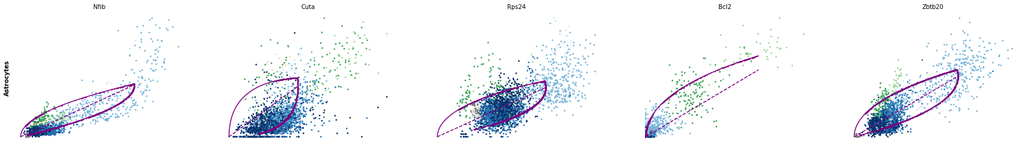

```python
scv.pl.scatter(adata, df['Astrocytes'][:5], ylabel='Astrocytes', frameon=False, size=30, linewidth=1.5, color='clusters')
```

## Pseudotime

Scvelo can compute its own pseudotime, based on a random-walk distance measures on the velocity graph. It measures the average number of steps it takes to reach a cell after start walking from one of the root cells. Scvelo infers the root cell implicitly from the velocity grpah.

```
computing terminal states
    identified 4 regions of root cells and 2 regions of end points .
    finished (0:00:00) --> added
    'root_cells', root cells of Markov diffusion process (adata.obs)
    'end_points', end points of Markov diffusion process (adata.obs)
```

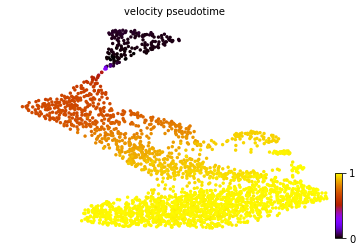

```python
scv.tl.velocity_pseudotime(adata)
scv.pl.scatter(adata, color='velocity_pseudotime', cmap='gnuplot')
```

## Latent time

Latent time works only with the dynamical model, and it show the latent time of the underlying process. The latent time represents the cell's internal clock and approximates the real time experienced by cells as they differentiate, based only on its transcriptional dynamics. It is often very close to the pseudotime.

```
computing latent time using root_cells as prior
    finished (0:00:00) --> added
    'latent_time', shared time (adata.obs)
```

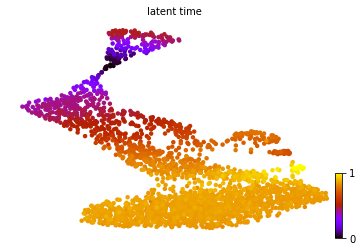

```python
scv.tl.latent_time(adata)
scv.pl.scatter(adata, color='latent_time', color_map='gnuplot', size=80)
```

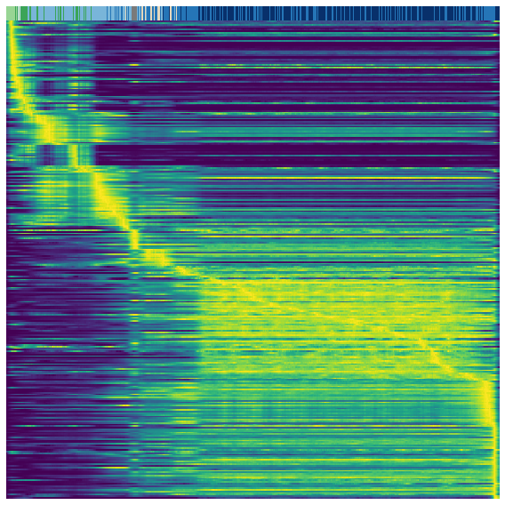

```python
top_genes = adata.var['fit_likelihood'].sort_values(ascending=False).index[:300]
scv.pl.heatmap(adata, var_names=top_genes, sortby='latent_time', col_color='clusters',
               n_convolve=50, yticklabels=False, figsize=(8, 8))
```

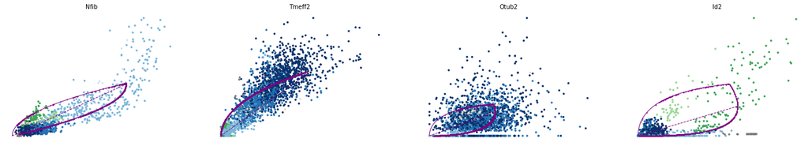

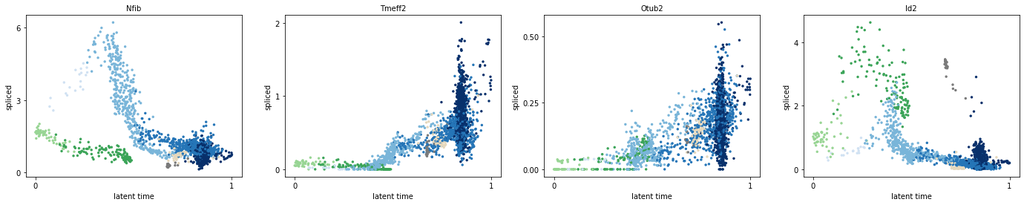

```python
var_names = ['Nfib', 'Tmeff2',  'Otub2', 'Id2']
scv.pl.scatter(adata, var_names, frameon=False)
scv.pl.scatter(adata, x='latent_time', y=var_names, frameon=True)
```

```python
pickle.dump(adata, open('/mnt/Data1/public_vignettes/scvelo_data/dentate_gyrus_filtered.dp', 'wb'))
```